# HomeworkOne - Practicum Problems

FateenAhmed

2024-02-03

## Problem 1

Load the iris sample dataset into R using a dataframe (it is a built-in dataset). Create a boxplot of each of the 4 features, and highlight the feature with the largest empirical IQR. Calculate the parametric standard deviation for each feature - do your results agree with the empirical values? Use the ggplot2 library from CRAN to create a colored boxplot for each feature, with a box-whisker per flower species. Which flower type exhibits a significantly different Petal Length/Width once it is separated from the other classes?

## Loading the Dataset and Libraries

```r
library(ggplot2)
data(iris)
head(iris)
```

```
##   Sepal.Length Sepal.Width Petal.Length Petal.Width Species
## 1          5.1         3.5          1.4         0.2  setosa
## 2          4.9         3.0          1.4         0.2  setosa
## 3          4.7         3.2          1.3         0.2  setosa
## 4          4.6         3.1          1.5         0.2  setosa
## 5          5.0         3.6          1.4         0.2  setosa
## 6          5.4         3.9          1.7         0.4  setosa
```

## Boxplot of Feature

Visualizing the data distributions through box-plots. In this case, the boxplot shows the four different measurements from iris flowers.

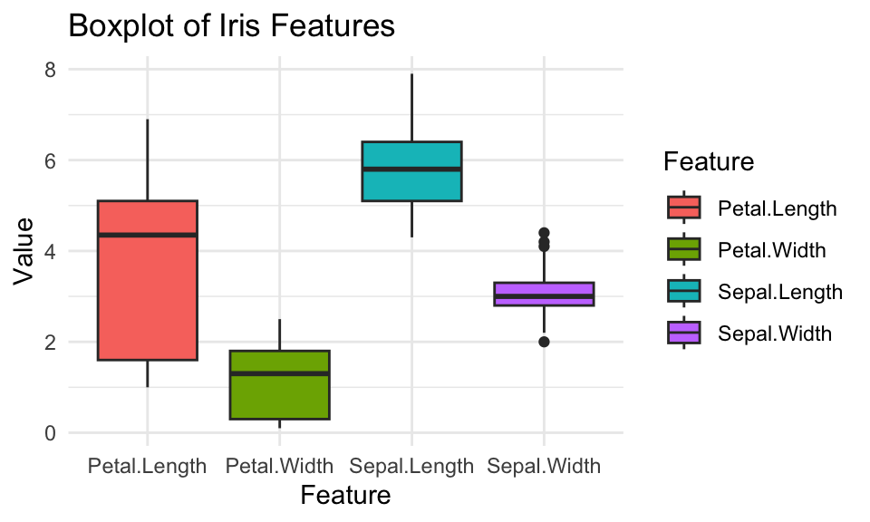

```r
#converting the data to a long format
iris_long <- gather(iris, key = "Feature", value = "Value", -Species)

#creating boxplots for each feature
ggplot(iris_long, aes(x = Feature, y = Value, fill = Feature)) +
  geom_boxplot() +
  labs(title = "Boxplot of Iris Features", x = "Feature", y = "Value") +
  theme_minimal()
```

From the above plots it can be inferred that - The petal length has the longest box, which indicates that the lengths of iris petals vary a lot. The petal width, and the lengths and widths of sepals—have shorter boxes, which implies that they don’t change as much from flower to flower. The few dots far from the boxes, indicate outliers which are the large or small measurements compared to the rest.

#### Therefore, it can said that the inter-quartile range for the petal length feature is the largent among other features

## Calculating Largest Emperical IQR

The Inter-Quartile Range for each feature is calculated and compared. The IQR provides a comparitive analysis of different features of a dataset.

```r
features <- c("Sepal.Length", "Sepal.Width", "Petal.Length", "Petal.Width")
iqr_val <- sapply(iris[features], IQR)
l_iqr_ftr <- names(which.max(iqr_val))
l_iqr_val <- max(iqr_val)

#printing the IQR for each feature
cat("IQR for each feature:\n")
```

```
## IQR for each feature:
```

```r
for (feature in names(iqr_val)) {
  cat(feature, ": ", iqr_val[feature], "\n")
}
```

```
## Sepal.Length :  1.3
## Sepal.Width :  0.5
## Petal.Length :  3.5
## Petal.Width :  1.5
```

```r
#printing max IQR and its feature
cat("\nThe feature with the largest IQR is", l_iqr_ftr, "with an IQR of", l_iqr_val, "\n")
```

```
##
## The feature with the largest IQR is Petal.Length with an IQR of 3.5
```

## Parametric Standard Deviation

The standard deviation for each feature is calculated and compared with the empirical IQR values. The standard deviation measures how spread the data is from the average value. A small SD indicates closely clustered data while a larger value indicates more spread out data.

```r
sd_val <- sapply(iris[features], sd)
sd_val
```

```
## Sepal.Length  Sepal.Width Petal.Length  Petal.Width
##    0.8280661    0.4358663    1.7652982    0.7622377
```

From the given values, it can be inferred that the feature ‘Petal.Length’ has the largest standard deviation of 1.7652982 which indicates that the data is more spreadout and confirms the empirical values of the IQR.

## Colored Boxplot per Flower Species

Creating a visualization to identify which flower type exhibits significantly different petal lengths/widths.

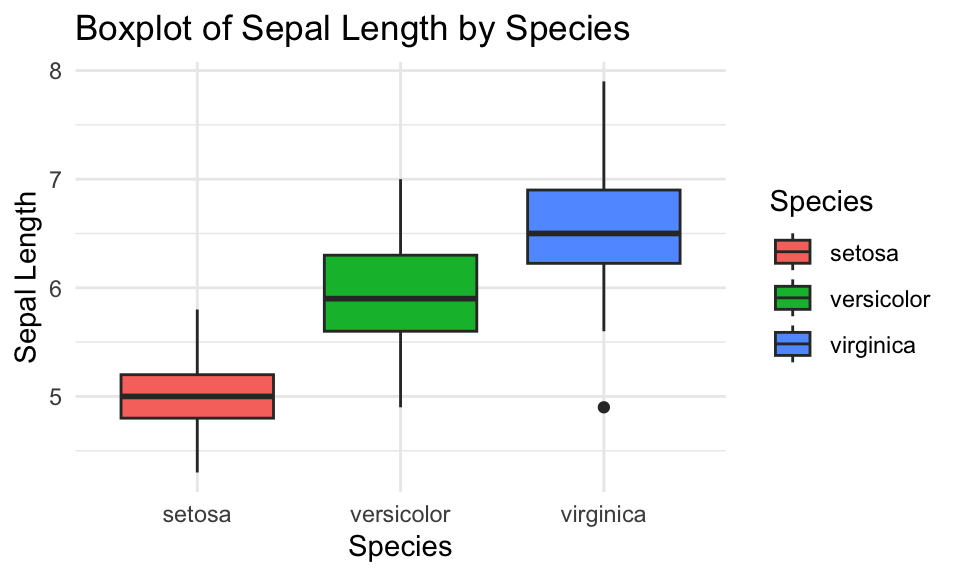

```r
#boxplot for Sepal Length by Species
ggplot(iris, aes(x = Species, y = Sepal.Length, fill = Species)) +
  geom_boxplot() +
  labs(title = "Boxplot of Sepal Length by Species", x = "Species", y = "Sepal Length") +
  theme_minimal()
```

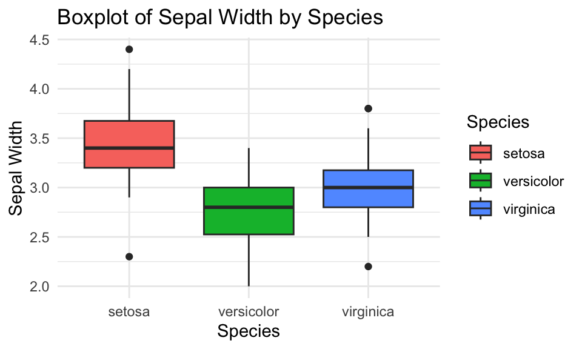

```r
#boxplot for Sepal Width by Species
ggplot(iris, aes(x = Species, y = Sepal.Width, fill = Species)) +
  geom_boxplot() +
  labs(title = "Boxplot of Sepal Width by Species", x = "Species", y = "Sepal Width") +
  theme_minimal()
```

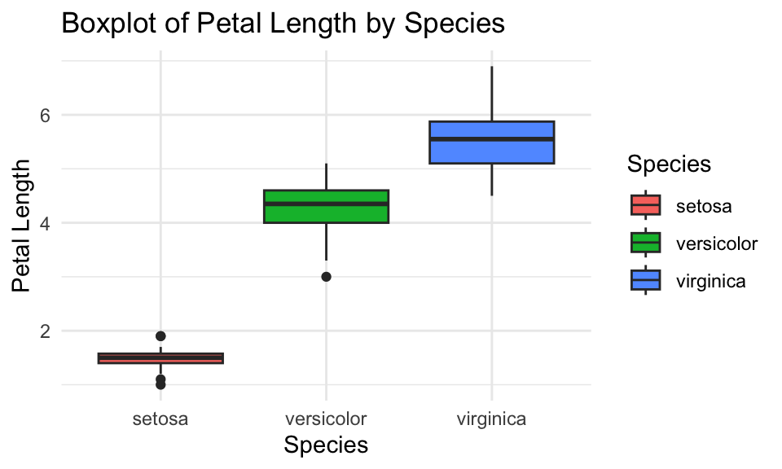

```r
#boxplot for Petal Length by Species
ggplot(iris, aes(x = Species, y = Petal.Length, fill = Species)) +
  geom_boxplot() +
  labs(title = "Boxplot of Petal Length by Species", x = "Species", y = "Petal Length") +
  theme_minimal()
```

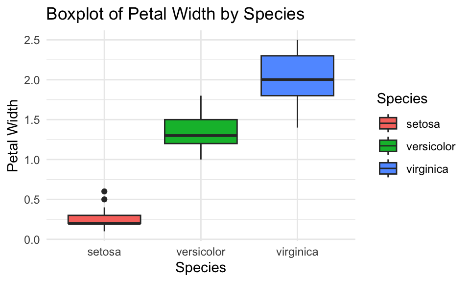

```r
#boxplot for Petal Width by Species
ggplot(iris, aes(x = Species, y = Petal.Width, fill = Species)) +
  geom_boxplot() +
  labs(title = "Boxplot of Petal Width by Species", x = "Species", y = "Petal Width") +
  theme_minimal()
```

## Analysis

From the above plots it can be inferred that -

1. The median sepal length increases from setosa to virginica. The virginica species shows a larger variation in sepal length than the other two species.
2. The setosa species has a wider sepal compared to the others, and there are a few outliers on both the lower and higher ends. This implies that setosa’s sepal width varies more than the other species.
3. There is a large difference in petal lengths among the three species. The setosa species has the smallest petal length, and there is a large difference in length, indicating it’s a distinct group. The versicolor and virginica species have similarity in length, but virginica has longer petals size.
4. The setosa species also has the smallest petal width, versicolor is intermediate, and virginica has the largest petal width.

#### Therefore, Setosa species exhibits a significantly different Petal Length and Width when compared to other two species.

# Problem 2

Load the trees sample dataset into R using a dataframe (it is a built-in dataset), and produce a 5-number summary of each feature. Create a histogram of each variable - which variables appear to be normally distributed based on visual inspection? Do any variables exhibit positive or negative skewness? Install the moments library from CRAN use the skewness function to calculate the skewness of each variable. Do the values agree with the visual inspection?

## Loading the ‘trees’ Dataset and Checking Summary

```r
library(moments)
data(trees)
summary(trees)
```

```
##      Girth           Height       Volume
##  Min.   : 8.30   Min.   :63   Min.   :10.20
##  1st Qu.:11.05   1st Qu.:72   1st Qu.:19.40
##  Median :12.90   Median :76   Median :24.20
##  Mean   :13.25   Mean   :76   Mean   :30.17
##  3rd Qu.:15.25   3rd Qu.:80   3rd Qu.:37.30
##  Max.   :20.60   Max.   :87   Max.   :77.00
```

## Histograms of Variables

Plotting a histogram to vizualize the distrubtion of each variable

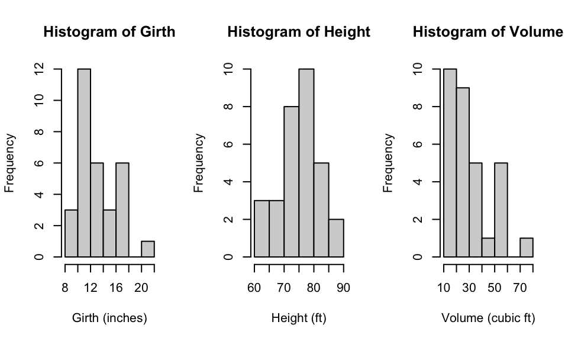

```r
#arranging plots
par(mfrow=c(1,3))
hist(trees$Girth, main="Histogram of Girth", xlab="Girth (inches)")
hist(trees$Height, main="Histogram of Height", xlab="Height (ft)")
hist(trees$Volume, main="Histogram of Volume", xlab="Volume (cubic ft)")
```

```r
#reset plots
par(mfrow=c(1,1))
```

From the above histogram plot, it can be inferred that -

1. Most trees have a girth around 10 to 14 inches, while a few trees have larger girths. The distribution has positive skewness, as there is a distribution further away from the on the right side. This indicates that there are some trees with significantly larger girths compared to the rest.
2. The height of the trees seems to be more symmetrically distributed, within the range 70 to 80 feet tall. This distribution looks closer to normal.
3. The volume histogram shows postive skewness in distribution, similar to girth. Most trees have a smaller volume, however a number of trees show higher volume. This indicates that while most trees have a modest volume, a few trees have much larger volumes.

## Skewness

The skewness measures the data’s distribution higher and lower values. A skewness close to 0 means that the data is evenly spread out. If the data is mostly distributed towards high values on the right it is referred to as positive skewness (>0) and if the data is mostly distributed towards low values on the left it is referred to as negative skewness (<0).

```r
skewness(trees$Girth)
```

```
## [1] 0.5263163
```

```r
skewness(trees$Height)
```

```
## [1] -0.374869
```

```r
skewness(trees$Volume)
```

```
## [1] 1.064357
```

## Analysis

From the given skewness measure it can be observed that -

1. The skewness value for Girth is positive (0.5263163), which implies that the data tilts towards the right with some higher values. This confirms the histogram where a number of trees with large girthwere present towards the right side of histogram.
2. The skewness value for Height is slightly negative (-0.374869), which implies that there is a slight tilt towards the left with some lower values. The histogram for height, shows an almost symmetric distribution, with a few lower values too.
3. The skewness value for Volume is positive (1.064357), which again implies that the data has strong rightward tilt due to some very high values. This is consistent with the histogram where there are some trees that have larger volume values.

## Problem 3

Load the auto-mpg sample dataset from the UCI Machine Learning Reposi- tory (auto-mpg.data) into R using a dataframe (Hint: You will need to use read.csv with url, and set the appropriate values for header,as.is, and sep). The horsepower feature has a few missing values with a ? - and will be treated as a string. Use the as.numeric casting function to obtain the column as a nu- meric vector, and replace all NA values with the median. How does this affect the value obtained for the mean vs the original mean when the records were ignored?

## Loading the Dataset

```r
url <- "http://archive.ics.uci.edu/ml/machine-learning-databases/auto-mpg/auto-mpg.data"
cols <- c("mpg", "cylinders", "displacement", "horsepower", "weight", "acceleration",
          "model_year", "origin", "car_name")
auto_mpg <- read.csv(url, sep = "", col.names = cols, header = FALSE, stringsAsFactors = FALSE, na.strings = "?")

#Converting horsepower to numeric vector
auto_mpg$horsepower <- as.numeric(auto_mpg$horsepower)

#Calculating total records
total_records <- nrow(auto_mpg)
cat("Total number of records in the dataset:", total_records, "\n")
```

```
## Total number of records in the dataset: 398
```

```r
# Counting the number of missing vals
num_missing_hp <- sum(is.na(auto_mpg$horsepower))
cat("Number of missing values in horsepower:", num_missing_hp, "\n")
```

```
## Number of missing values in horsepower: 6
```

```r
#Calculating the mean of horsepower
mean_hp_bef <- mean(auto_mpg$horsepower, na.rm = TRUE) # mean with NA values removed
cat("Mean horsepower before replacing NA:", mean_hp_bef, "\n")
```

```
## Mean horsepower before replacing NA: 104.4694
```

```r
#Calculating the median of horsepower
medhp <- median(auto_mpg$horsepower, na.rm = TRUE)
cat("The median horsepower is:", medhp, "\n")
```

```
## The median horsepower is: 93.5
```

```r
#Replacing NA values with the median
auto_mpg$horsepower[is.na(auto_mpg$horsepower)] <- medhp

#Calculating mean horsepower after replace
mean_hp_aft <- mean(auto_mpg$horsepower) # mean after replacing NA with median
cat("Mean horsepower after replacing NA:", mean_hp_aft, "\n")
```

```
## Mean horsepower after replacing NA: 104.304
```

The total number of records in the dataset is 398 and there are 6 missing values in the horsepower variable. As the proportion of missing data is relatively small, replacing the missing values with the median of the horsepower data has a minimal impact on the overall mean of the horsepower variable. A slight decrease from 104.4694 to 104.304 in the mean horsepower implies that the median has a slight an affect on the mean.

## Problem 4

Load the Boston sample dataset into R using a dataframe (it is part of the MASS package). Use lm to fit a regression between medv and lstat - plot the resulting fit and show a plot of fitted values vs. residuals. Is there a possible non-linear relationship between the predictor and response? Use the predict function to calculate values response values for lstat of 5, 10, and 15 - obtain confidence intervals as well as prediction intervals for the results - are they the same? Why or why not? Modify the regression to include lstat2 (as well lstat itself) and compare the R2 between the linear and non-linear fit - use ggplot2 and stat smooth to plot the relationship.

## Loading the Boston dataset

```r
data(Boston)
head(Boston)
```

```
##      crim zn indus chas   nox    rm  age    dis rad tax ptratio  black lstat
## 1 0.00632 18  2.31    0 0.538 6.575 65.2 4.0900   1 296    15.3 396.90  4.98
## 2 0.02731  0  7.07    0 0.469 6.421 78.9 4.9671   2 242    17.8 396.90  9.14
## 3 0.02729  0  7.07    0 0.469 7.185 61.1 4.9671   2 242    17.8 392.83  4.03
## 4 0.03237  0  2.18    0 0.458 6.998 45.8 6.0622   3 222    18.7 394.63  2.94
## 5 0.06905  0  2.18    0 0.458 7.147 54.2 6.0622   3 222    18.7 396.90  5.33
## 6 0.02985  0  2.18    0 0.458 6.430 58.7 6.0622   3 222    18.7 394.12  5.21
##   medv
## 1 24.0
## 2 21.6
## 3 34.7
## 4 33.4
## 5 36.2
## 6 28.7
```

#### Fitting a linear regression model

```r
lm_fit <- lm(medv ~ lstat, data=Boston)
summary(lm_fit)
```

```
##
## Call:
## lm(formula = medv ~ lstat, data = Boston)
##
## Residuals:
##     Min      1Q  Median      3Q     Max
## -15.168  -3.990  -1.318   2.034  24.500
##
## Coefficients:
##             Estimate Std. Error t value Pr(>|t|)
## (Intercept) 34.55384    0.56263   61.41   <2e-16 ***
## lstat       -0.95005    0.03873  -24.53   <2e-16 ***
## ---
## Signif. codes:  0 '***' 0.001 '**' 0.01 '*' 0.05 '.' 0.1 ' ' 1
##
## Residual standard error: 6.216 on 504 degrees of freedom
## Multiple R-squared:  0.5441, Adjusted R-squared:  0.5432
## F-statistic: 601.6 on 1 and 504 DF,  p-value: < 2.2e-16
```

#### Plotting the fit

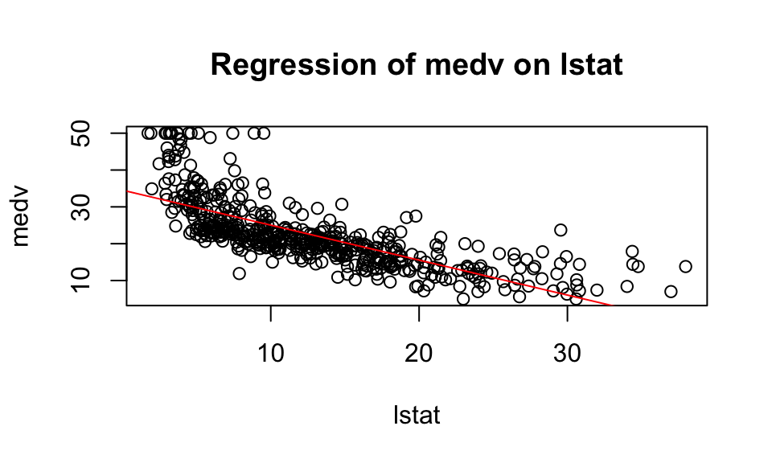

```r
plot(Boston$lstat, Boston$medv, main="Regression of medv on lstat",
     xlab="lstat", ylab="medv")
abline(lm_fit, col="red")
```

#### Plotting fitted values vs residuals

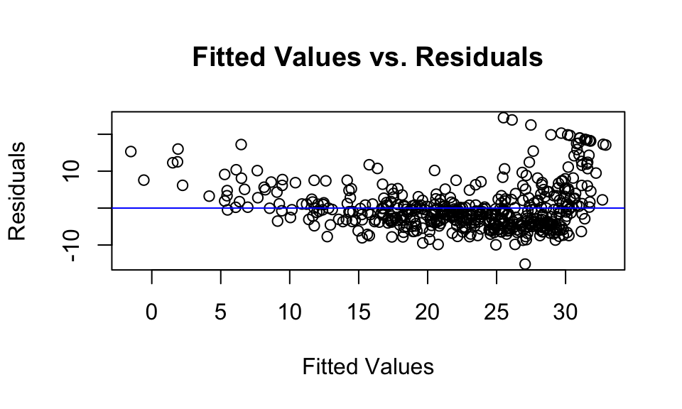

```r
fit_vals <- lm_fit$fitted.values
res <- lm_fit$residuals

plot(fit_vals, res, main="Fitted Values vs. Residuals",
     xlab="Fitted Values", ylab="Residuals")
abline(h=0, col="blue")
```

#### Predictions for specific lstat values

```r
newpred <- data.frame(lstat=c(5, 10, 15))
pred_conf <- predict(lm_fit, newdata=newpred, interval="confidence")
print("Confidence Intervals")
```

```
## [1] "Confidence Intervals"
```

```r
print(pred_conf)
```

```
##        fit      lwr      upr
## 1 29.80359 29.00741 30.59978
## 2 25.05335 24.47413 25.63256
## 3 20.30310 19.73159 20.87461
```

```r
pred_pred <- predict(lm_fit, newdata=newpred, interval="prediction")
print("Prediction Intervals")
```

```
## [1] "Prediction Intervals"
```

```r
print(pred_pred)
```

```
##        fit       lwr      upr
## 1 29.80359 17.565675 42.04151
## 2 25.05335 12.827626 37.27907
## 3 20.30310  8.077742 32.52846
```

#### Non-linear regression with lstat and lstat^2

```r
lm_fit_nl <- lm(medv ~ lstat + I(lstat^2), data=Boston)
summary(lm_fit_nl)
```

```
##
## Call:
## lm(formula = medv ~ lstat + I(lstat^2), data = Boston)
##
## Residuals:
##      Min       1Q   Median       3Q      Max
## -15.2834  -3.8313  -0.5295   2.3095  25.4148
##
## Coefficients:
##              Estimate Std. Error t value Pr(>|t|)
## (Intercept) 42.862007   0.872084   49.15   <2e-16 ***
## lstat       -2.332821   0.123803  -18.84   <2e-16 ***
## I(lstat^2)   0.043547   0.003745   11.63   <2e-16 ***
## ---
## Signif. codes:  0 '***' 0.001 '**' 0.01 '*' 0.05 '.' 0.1 ' ' 1
##
## Residual standard error: 5.524 on 503 degrees of freedom
## Multiple R-squared:  0.6407, Adjusted R-squared:  0.6393
## F-statistic: 448.5 on 2 and 503 DF,  p-value: < 2.2e-16
```

#### Visualize

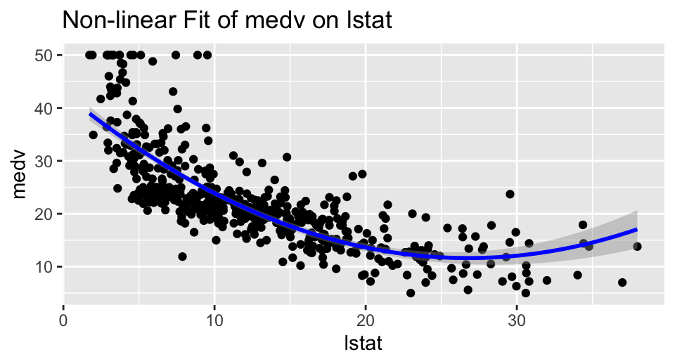

```r
library(ggplot2)

ggplot(Boston, aes(x=lstat, y=medv)) +
  geom_point() +
  geom_smooth(method="lm", formula=y ~ x + I(x^2), color="blue") +
  labs(title="Non-linear Fit of medv on lstat", x="lstat", y="medv")
```

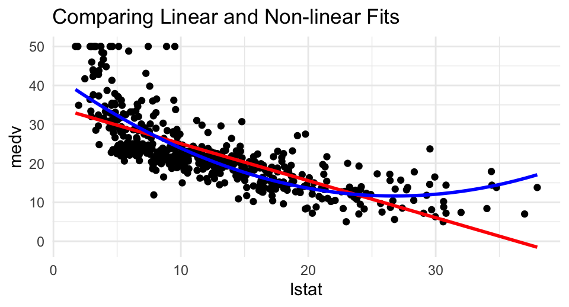

```r
base_plot <- ggplot(Boston, aes(x = lstat, y = medv)) +
  geom_point() +
  labs(title = "Comparing Linear and Non-linear Fits", x = "lstat", y = "medv")

#Adding the linear fit
linear_fit_plot <- base_plot +
  stat_smooth(method = "lm", formula = y ~ x, col = "red", se = FALSE, linewidth = 1)

#Adding the non-linear fit
non_linear_fit_plot <- linear_fit_plot +
  stat_smooth(method = "lm", formula = y ~ poly(x, 2), col = "blue", se = FALSE, linewidth = 1) +
  theme_minimal()
non_linear_fit_plot
```

## References

I referred and utlised these webpages for assistance in code and debugging in R.

1. http://www.cookbook-r.com/Manipulating_data/Converting_data_between_wide_and_long_format/
2. https://rpubs.com/bpbond/727256
3. https://rpubs.com/T_Fox_99/569480
4. https://rdrr.io/r/stats/lm.html
5. https://stat-ata-asu.github.io/ISLR-CHAP3-LAB-SC/LabChap3-Solution.html